# Principle Component Regression

Atakan Düzgün

## The prostate data frame has 97 rows and 9 columns. A study on 97 men with prostate cancer who were due to receive a radical prostatectomy.

```r
library(faraway)
library(pls)
data("prostate")
summary(prostate)
```

```
##      lcavol           lweight           age             lbph
##  Min.   :-1.3471   Min.   :2.375   Min.   :41.00   Min.   :-1.3863
##  1st Qu.: 0.5128   1st Qu.:3.376   1st Qu.:60.00   1st Qu.:-1.3863
##  Median : 1.4469   Median :3.623   Median :65.00   Median : 0.3001
##  Mean   : 1.3500   Mean   :3.653   Mean   :63.87   Mean   : 0.1004
##  3rd Qu.: 2.1270   3rd Qu.:3.878   3rd Qu.:68.00   3rd Qu.: 1.5581
##  Max.   : 3.8210   Max.   :6.108   Max.   :79.00   Max.   : 2.3263
##       svi              lcp             gleason          pgg45
##  Min.   :0.0000   Min.   :-1.3863   Min.   :6.000   Min.   :  0.00
##  1st Qu.:0.0000   1st Qu.:-1.3863   1st Qu.:6.000   1st Qu.:  0.00
##  Median :0.0000   Median :-0.7985   Median :7.000   Median : 15.00
##  Mean   :0.2165   Mean   :-0.1794   Mean   :6.753   Mean   : 24.38
##  3rd Qu.:0.0000   3rd Qu.: 1.1786   3rd Qu.:7.000   3rd Qu.: 40.00
##  Max.   :1.0000   Max.   : 2.9042   Max.   :9.000   Max.   :100.00
##       lpsa
##  Min.   :-0.4308
##  1st Qu.: 1.7317
##  Median : 2.5915
##  Mean   : 2.4784
##  3rd Qu.: 3.0564
##  Max.   : 5.5829
```

#### lcavol - log(cancer volume)

#### lweight - log(prostate weight)

#### lbph - log(benign prostatic hyperplasia amount)

#### svi - seminal vesicle invasion

#### lcp - log(capsular penetration)

#### lpsa - log(prostate specific antigen)

```r
set.seed(120)

index <- sample(1:nrow(prostate),round(0.75*nrow(prostate)))
Datatrain <- prostate[index,-8]
datatest <- prostate[-index,-8]
```

#### “lcavol” as the dependent variable.

```r
lmod<-lm(lcavol ~.,data=Datatrain)
vif(lmod)
```

```
##  lweight      age     lbph      svi      lcp  gleason     lpsa
## 1.654734 1.451734 1.410485 2.036051 2.565614 1.765376 1.899842
```

#### When we set up the least square regression model and look at the vif values, it is seen that there is no interrelationship problem in the data.

```r
rmse <- function(x,y) sqrt(mean((x-y)^2))

rmse(predict(lmod,Datatrain),Datatrain$lcavol)
```

```
## [1] 0.6517846
```

```r
rmse(predict(lmod,datatest),datatest$lcavol)
```

```
## [1] 0.7912875
```

#### RMSE values for training and testing datasets are not significantly different. This difference indicates that there is no collinearity problem.

```r
pcrmod <- pcr(lcavol ~., data=Datatrain,scale=T)
summary(pcrmod)
```

```
## Data:    X dimension: 73 7
##  Y dimension: 73 1
## Fit method: svdpc
## Number of components considered: 7
## TRAINING: % variance explained
##         1 comps  2 comps  3 comps  4 comps  5 comps  6 comps  7 comps
## X         43.44    65.64    75.51    84.43    91.05    96.34   100.00
## lcavol    56.28    60.61    60.61    60.90    61.67    64.09    66.62
```

#### The variability in the response with 2 components is approximately 60.61% can be explained.

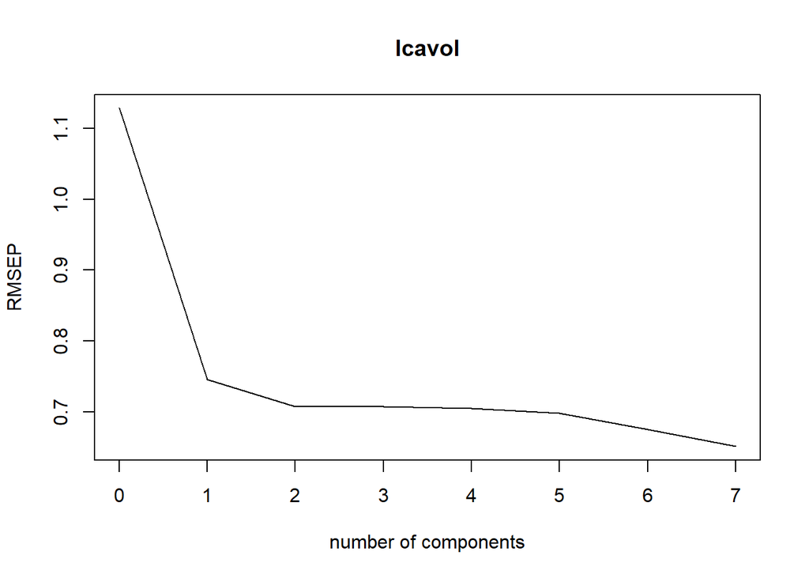

```r
validationplot(pcrmod,val.type = "RMSE")
```

```r
pcrmse <- RMSEP(pcrmod)
pcrmse
```

```
## (Intercept)      1 comps      2 comps      3 comps      4 comps      5 comps
##      1.1281       0.7459       0.7080       0.7080       0.7054       0.6985
##     6 comps      7 comps
##      0.6761       0.6518
```

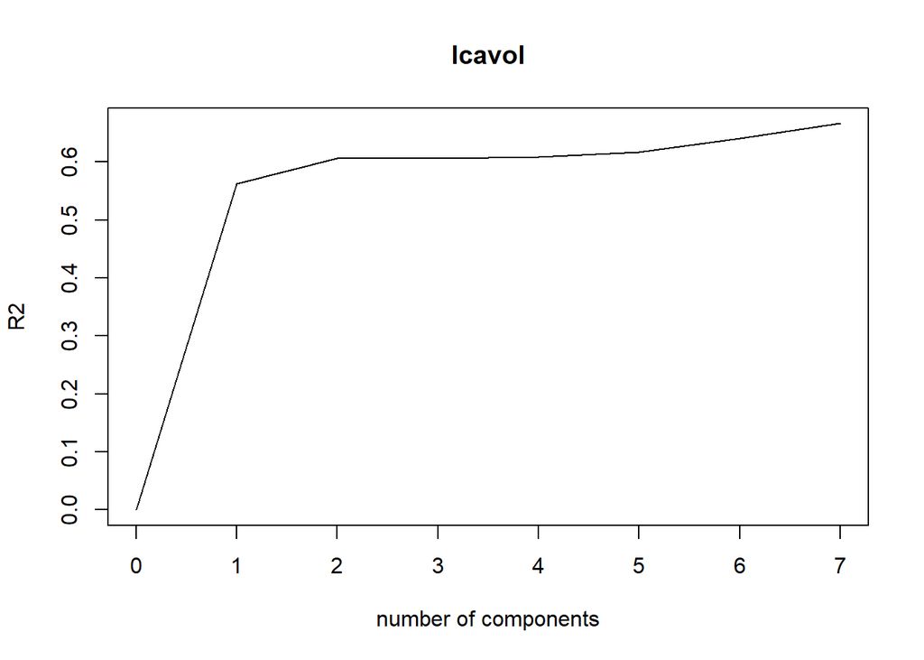

```r
validationplot(pcrmod,val.type = "R2")
```

#### The 7 components seem to be the best in terms of performance on the traim data set.

#### However, with 2 Components, we obtain a result close to 7 components, and we have reduced the processing intensity and optimized the model.

#### Installed with 2 components coefficients of the model

```r
coef(pcrmod,ncomp=2)
```

```
## , , 2 comps
##
##              lcavol
## lweight  0.07025350
## age      0.11364604
## lbph    -0.00283218
## svi      0.26566430
## lcp      0.28687120
## gleason  0.23289374
## lpsa     0.22308455
```

```r
rmse(predict(pcrmod,ncomp = 2),Datatrain$lcavol)
```

```
## [1] 0.7080362
```

```r
rmse(predict(pcrmod,datatest,ncomp = 2),datatest$lcavol)
```

```
## [1] 0.9288449
```

#### Our prediction performance on test data has decreased. It will be more accurate to use the cross validation method when determining the optimal number of components.

### Fundamental Component Analysis with Cross-Validation for 1000 times

```r
set.seed(100)

comp<- NULL
for(i in 1:1000)

{

pcrmod1 <- pcr(lcavol ~.,data=Datatrain,scale=T,validation="CV")

pcrCV <- RMSEP(pcrmod1,estimate="CV")
pcrCV

comp[i] <- which.min(pcrCV$val)

}


comp <- as.factor(comp)
summary(comp)
```

```
##   3   4   7   8
## 500   2  10 488
```

#### While 2 (3-1) components were selected as the optimal component 500 times in the Fundamental Component Analysis with Cross-Validation, which was done 1000 times,

#### 7 (8-1) components were selected as the optimal component 488 times.

#### According to these results, my interpretation is that it is appropriate to use 2 components to make this model optimal.